# Deaths per capita from COVID-19 are more informative than confirmed cases

Rory Nolan

2020-04-05

The rate of testing for COVID-19 is increasing in many countries. As such, using the number of confirmed cases over time is not a reliable method for tracking the spread of the disease. Nevertheless, many articles—including [this one](https://www.ft.com/content/a26fbf7e-48f8-11ea-aeb3-955839e06441) in the *Financial Times*—still talk about the number of confirmed cases. That article also focuses on number of deaths though, which is much better and leads us to what I think should be used.

# We should be using deaths per capita

For timelining, I’ll use days since the tenth confirmed death from COVID-19 in a particular country, just like the *Financial Times* article.

## Deaths per capita will lag other measures

I don’t mean to say that deaths per capita is the only useful thing. It actually lags other measures (in particular the number of infected individuals) by a few days because the disease does not kill quickly. In particular, if a countries rate of testing is steady or increasing but the absolute number of people testing positive per day is decreasing, that’s a great sign and a sign that you’ll see sooner than a drop in deaths.

# Data source, preparation and limitations

Johns Hopkins University Center for Systems Science and Engineering (JHU CSSE) has put together a great [COVID-19 data repository](https://github.com/CSSEGISandData/COVID-19). Note that I’ve smoothed the data to make the plots more readable. This means that only sustained changes will appear on the plots (e.g. a one-day drop in deaths will be smoothed out). This is a good thing as it prevents us from reading too much into single data. Bear in mind that different countries have different measurement methods and capabilities, so they aren’t strictly comparable. However, provided that within a given country, the measurements are done in a consistent manner, one can still do reliable comparisons of the *shapes* of the countries’ curves.

## A note on social distancing

Social distancing is mostly new (where it exists at all) and due to the long (approximately 2-week) latency period of the virus (*latency* is roughly the period between a person encountering the virus and showing symptoms of infection), we probably won’t see the benefit of social distancing in these statistics for at least another week. If by then there’s still no improvement, that would be cause for huge concern. In Taiwan, for example, the government is using people’s mobile phone location to ensure they stay at home. If you leave home without permission, the police come and find you within a half hour and make you return home. That is a much better lockdown than exists anywhere in the western world. I was in a crowded supermarket yesterday in Oakland, California. I’d be surprised if there wasn’t a single transmission in there that day. The local lake is more crowded than ever with people who are desperate to get outside. They *try* to keep their distance, but they’re not as distant as they would be if they’d stayed at home. Are we doing *enough*? We’ll have a better idea in a few weeks.

# World data

## All countries

I’m going to limit the data to countries that have reported at least 100 deaths. First up, I’ll just plot all of these countries. I’ll give a table of country codes at the end. Note that the data is not cumulative: each data point is deaths per million on that day. The lines are colored by how bad the situation is in that country right now: how many deaths there were there yesterday.

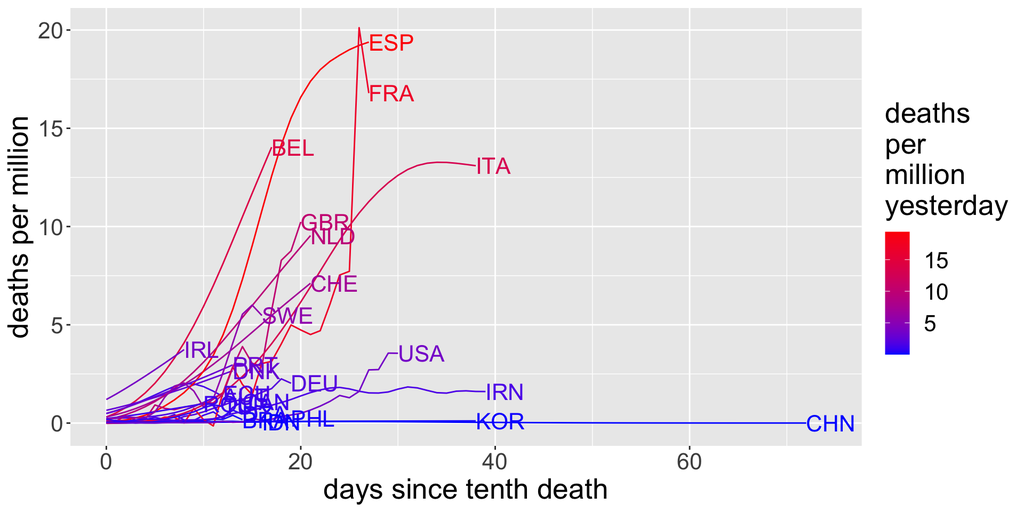

## Countries with less than 10 deaths per million yesterday

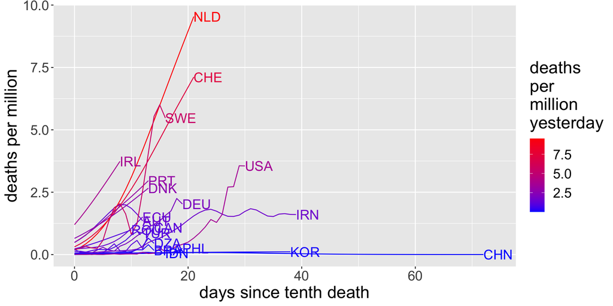

## Countries with less than 2 death per million yesterday

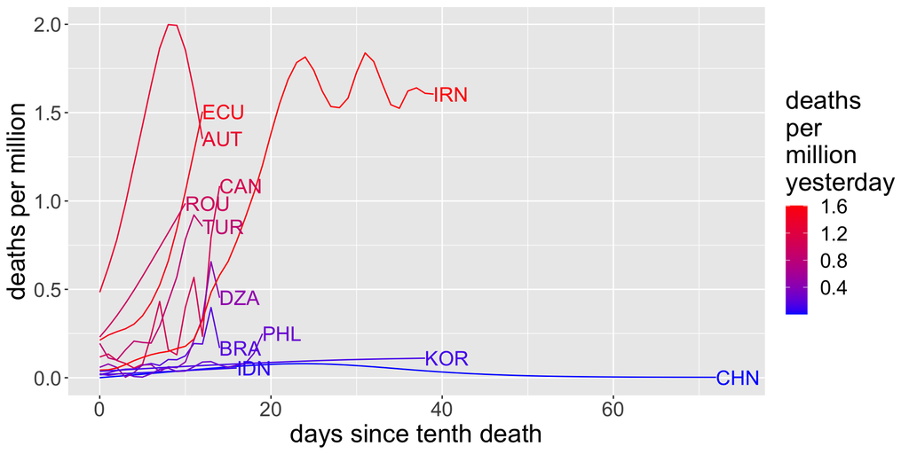

# US data

I’m going to use the same limitations for the US state data: states with at least 100 deaths. For reference, I’m also going to include Spain and Italy.

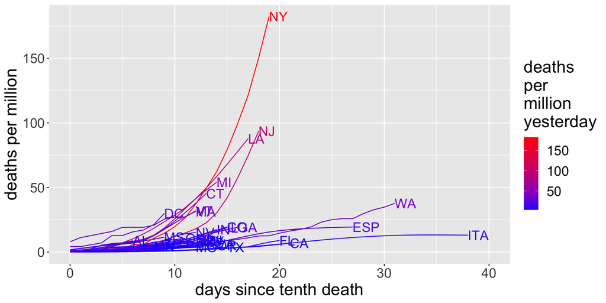

## States with fewer deaths per million than Italy yesterday

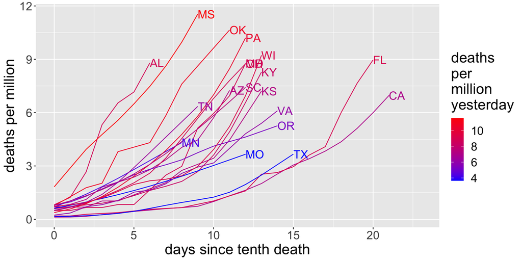

# Appendix

| iso3c | country | iso3c | country |
| --- | --- | --- | --- |
| AUT | Austria | GBR | United Kingdom |
| BEL | Belgium | IDN | Indonesia |
| BRA | Brazil | IRL | Ireland |
| CAN | Canada | IRN | Iran |
| CHE | Switzerland | ITA | Italy |
| CHN | China | KOR | Korea, South |
| DEU | Germany | NLD | Netherlands |
| DNK | Denmark | PHL | Philippines |
| DZA | Algeria | PRT | Portugal |
| ECU | Ecuador | ROU | Romania |
| ESP | Spain | SWE | Sweden |
| FRA | France | TUR | Turkey |